# UNICEF Consultancy Assessment Report

# 1 Introduction

These groups show how well each country is doing in terms of achieving the **Sustainable Development Goal (SDG)** objective for under-five mortality, which is 25 deaths per 1,000 live births by 2030. While Acceleration Needed indicates countries who are off-track and need to make faster progress, countries that have Achieved the target or are On Track to accomplish it are those with better child survival results.

## 1.1 Data Sources:

This assessment integrates multiple data sources to enable robust, population-weighted analyses. National coverage estimates for ANC4, and SBA were sourced from UNICEF’s global maternal and newborn health coverage databases. The number of live births per country was obtained from the WPP 2022 dataset. Lastly, country classifications for progress toward the Sustainable Development Goal (SDG) target on under-five mortality (U5MR) – categorized as Achieved, On Track, or Acceleration Needed – were based on data provided by UNICEF. These datasets were cleaned and harmonized to ensure consistency, including aligning country identifiers, selecting comparable years (primarily 2018–2022), and addressing missing values. This combined set of data is used to calculate population-weighted values and determine the significance of trends across countries.

# 2 Findings and Interpretation of Coverage Comparisons

## 2.1 Antenatal Care (ANC4) Coverage

The 2022 population-weighted analysis of ANC4 coverage reveals notable disparities across U5MR progress categories. Countries that have already Achieved the under-five mortality target exhibit the highest ANC4 coverage at 90.8%, reflecting strong access to essential prenatal care services. In contrast, countries in the Acceleration Needed category report a lower but still substantial coverage rate of 72.9%, suggesting ongoing gaps in service availability or uptake. Most unexpectedly, On Track countries display the lowest weighted ANC4 coverage at 45.5%, a counterintuitive result given their classification as progressing toward the U5MR goal. This discrepancy may point to structural weaknesses in maternal health service delivery, data limitations, or a lag between maternal care investments and observed child mortality outcomes.

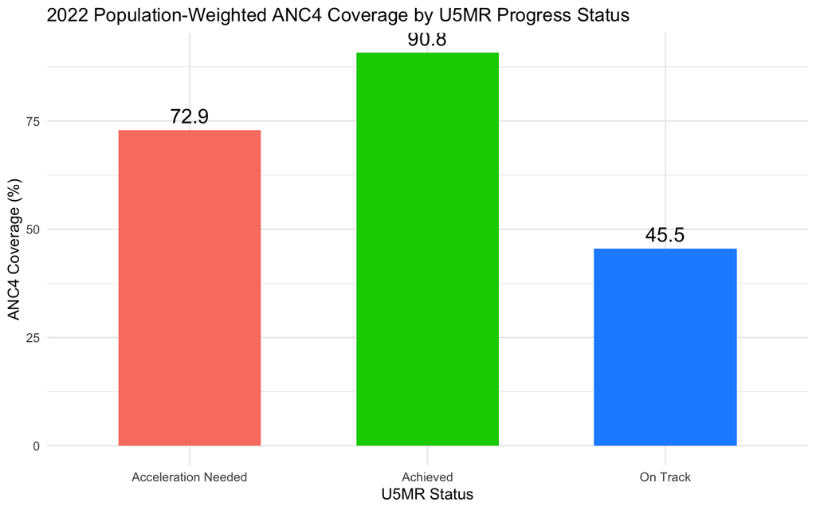

**Interpretation:** Countries that have Achieved U5MR targets show the highest population-weighted ANC4 coverage, suggesting robust maternal health systems. While countries labeled *Acceleration Needed* still fall behind, they outperform *On Track* countries in this specific indicator, a counter-intuitive finding that may reflect limitations in service delivery data, differences in programmatic emphasis, or recent fluctuations in coverage trends.

**This pattern highlights a critical insight**: U5MR progress does not always align with antenatal care coverage. Some “On Track” countries may be improving child survival through targeted neonatal interventions or other health system strategies, while still struggling to scale up comprehensive ANC services. This divergence underscores the need for a multi-dimensional approach to maternal and child health, ensuring that progress on under-five mortality is not decoupled from sustained investments in maternal care.

## 2.2 Skilled Birth Attendance (SBA) Coverage

The 2022 population-weighted analysis of Skilled Birth Attendance (SBA) coverage similarly highlights disparities across U5MR progress categories. Countries that have Achieved the under-five mortality target report the highest SBA coverage at 95.9%, reflecting near-universal access to skilled delivery care. *Acceleration Needed* countries follow with a moderately high rate of 87.7%, suggesting progress but continued challenges in ensuring consistent access to professional care during childbirth.

Unexpectedly, *On Track* countries report the lowest weighted SBA coverage at 71.6%, which is inconsistent with their classification as making adequate progress toward U5MR targets. This may reflect delayed investment in maternal health systems, data gaps, or a disconnect between service delivery and mortality outcomes. These findings reinforce the critical importance of targeted policy and programmatic interventions — especially in “On Track” and “Acceleration Needed” countries — to scale up skilled birth attendance and reduce maternal and neonatal health risks.

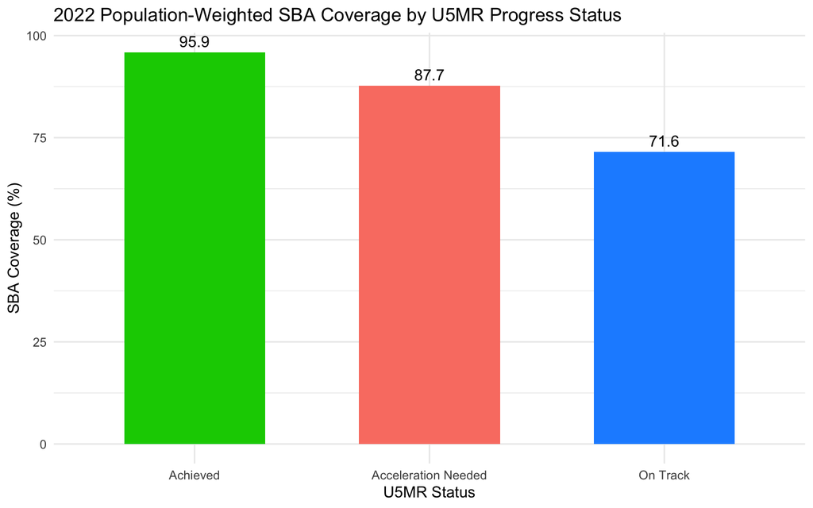

**Interpretation:** In 2022, population-weighted SBA coverage was highest in countries that had Achieved U5MR targets (95.9%), followed by *Acceleration Needed* countries (87.7%), and lowest in *On Track* countries (71.6%). This unexpected pattern suggests that while Achieved countries have maintained strong maternal health systems, *On Track* countries may be facing hidden service delivery gaps despite progress in child mortality outcomes. The relatively strong performance of *Acceleration Needed* countries may reflect focused global efforts or recent health investments. These disparities highlight the need to align service coverage improvements with mortality reduction goals to ensure sustainable and equitable maternal care progress.